# Final Project Notebook

DS 5001 Text as Data

# Metadata

- Full Name: Caroline Kranefuss
- Userid: fty3dt
- GitHub Repo URL: https://github.com/caroline-kranefuss/evolving_sentiment_climate
- UVA Box URL: https://virginia.box.com/s/dh7tehp9xv7j4f3kkxls3jjvk1evgbbx

# Overview

The goal of the final project is for you to create a **digital analytical edition** of a corpus using the tools, practices, and perspectives you’ve learning in this course. You will select a corpus that has already been digitized and transcribed, parse that into an F-compliant set of tables, and then generate and visualize the results of a series of fitted models. You will also draw some tentative conclusions regarding the linguistic, cultural, psychological, or historical features represented by your corpus. The point of the exercise is to have you work with a corpus through the entire pipeline from ingestion to interpretation.

Specifically, you will acquire a collection of long-form texts and perform the following operations:

- **Convert** the collection from their source formats (F0) into a set of tables that conform to the Standard Text Analytic Data Model (F2).
- **Annotate** these tables with statistical and linguistic features using NLP libraries such as NLTK (F3).
- **Produce** a vector representation of the corpus to generate TFIDF values to add to the TOKEN (aka CORPUS) and VOCAB tables (F4).
- **Model** the annotated and vectorized model with tables and features derived from the application of unsupervised methods, including PCA, LDA, and word2vec (F5).
- **Explore** your results using statistical and visual methods.
- **Present** conclusions about patterns observed in the corpus by means of these operations.

When you are finished, you will make the results of your work available in GitHub (for code) and UVA Box (for data). You will submit to Gradescope (via Canvas) a PDF version of a Jupyter notebook that contains the information listed below.

# Some Details

- Please fill out your answers in each task below by editing the markdown cell.
- Replace text that asks you to insert something with the thing, i.e. replace `(INSERT IMAGE HERE)` with an image element, e.g. `![](image.png)`.
- For URLs, just paste the raw URL directly into the text area. Don't worry about providing link labels using `[label](link)`.
- Please do not alter the structure of the document or cell, i.e. the bulleted lists.
- You may add explanatory paragraphs below the bulleted lists.
- Please name your tables as they are named in each task below.
- Tasks are indicated by headers with point values in parentheses.

# Raw Data

## Source Description (1)

**Provide a brief description of your source material, including its provenance and content. Tell us where you found it and what kind of content it contains.**

Upon the inception of this project, I found myself curious about how the sentiment and urgency in climate change-related scientific literature has evolved. I myself am conducting research in climate and, while I plan to maintain an unbiased and professional tone in the article I write, do feel an increasing sense of urgency as the climate warms more and more. (This urgency actually led me to switch fields from medical technology to environmental consulting - both important fields but one more personally prescient - but that's a story for another time.)

I dug in to creating a corpus but immediately encountered difficulties: most scientific journals publish PDFs, not JSONs, XMLs, or HTMLs. Through some digging, I found PeerJ, a journal that publishes every article in XML format, among others.

I'd hoped to explore a wide breadth of time but found that XMLs have only recently begun to be published - the latest year I found on PeerJ was 2013 - so limited my search to the decade between 2013 and 2023 in five-year increments.

I needed at least 500,000 observations in my corpus (sequence of word tokens) so wanted to source about 30 articles from 2013, 2018, and 2023 each for a total of nearly 100 articles. 2013 only had 18 articles on PeerJ, so to compensate, I chose 37 articles from 2018 (first two pages of search results) and 37 from 2023 (to match 2018).

To ensure relevance to and impact on the field, I origincally filtered articles to have 30 or more citations, but needed to remove this filter to obtain enough articles per year. I'd hoped to choose the top 30 most cited articles per year but was unable to do so on PeerJ, so simply sorted by PeerJ's determination of relevance to the query "climate change". PeerJ's determiniation of relevance is unclear, and this is something to explore in future project. The most relevant articles per year, after meeting these described criteria, have then been chosen to comprise my corpus.

## Source Features (1)

Add values for the following items. (Do this for all following bulleted lists.)

- Source URL: Different for each article, searchable on PeerJ or Google Scholar
- UVA Box URL: https://virginia.box.com/s/jeqo6gzxsupuyaiibsev2cuhmi3zpqm2
- Number of raw documents: 92
- Total size of raw documents (e.g. in MB): 15 MB
- File format(s), e.g. XML, plaintext, etc.: XML

## Source Document Structure (1)

**Provide a brief description of the internal structure of each document. That, describe the typical elements found in document and their relation to each other. For example, a corpus of letters might be described as having a date, an addressee, a salutation, a set of content paragraphs, and closing. If they are various structures, state that.**

Each article follows the same format. Key components include id, title, author(s), date of publication, and keywords. Articles are comprised of an abstract, a body, a set of references, and an optional appendix. All of these components were included in the analysis. PNG images were not included, but figure legends that are text (and not part of the image PNG) are, because the libraries used to parse the data cannot process image content.

The abstract describes the main idea of the paper, while the body comprises the article itself. The body is broken up into sections (usually Introduction, Materials and/or Methods, Results, Discussion, and Conclusions and/or Future Directions), paragraphs, sentences, and word tokens.

Each of these sections have sec, title, p (paragraph), fig(ure), and design (caption, graphic, etc.) tags.

Other components in the XML structure include journal id, publisher, a breakdown of author name(s) to given- and sur- names, volume of the journal, permissions, and funding information.

However, at the permission of Professor Alvarado, I have omitted structure between document and sentence; that is, I am not tracking section or paragraph as part of my OHCO (to be discussed later) due to HTML conversion complications as well as due to the nature of my research question which is primarily year- and document-based more than paragraph- or section-based.

# Parsed and Annotated Data

Parse the raw data into the three core tables of your addition: the `LIB`, `CORPUS`, and `VOCAB` tables.

These tables will be stored as CSV files with header rows.

You may consider using `|` as a delimitter.

Provide the following information for each.

## LIB (2)

The source documents the corpus comprises. These may be books, plays, newspaper articles, abstracts, blog posts, etc.

Note that these are *not* documents in the sense used to describe a bag-of-words representation of a text, e.g. chapter.

- UVA Box URL: https://virginia.box.com/s/2qwgjcdibtr3rawsxf1kgvrh8akpq8w0
- GitHub URL for notebook used to create: https://github.com/caroline-kranefuss/evolving_sentiment_climate/blob/main/notebooks/create_tables.ipynb
- Delimitter: |
- Number of observations: 92 (number of articles)
- List of features, including at least three that may be used for model summarization (e.g. date, author, etc.): doc_id, doc_title,doc_1st_author, year, sent_str, num_words, num_chars
- Average length of each document in characters: 38,815 (In words: 5,712)

## CORPUS (2)

The sequence of word tokens in the corpus, indexed by their location in the corpus and document structures.

- UVA Box URL: https://virginia.box.com/s/duqs5olz2ljry0b30aa7rkndr5f2pgsn
- GitHub URL for notebook used to create: https://github.com/caroline-kranefuss/evolving_sentiment_climate/blob/main/notebooks/create_tables.ipynb
- Delimitter: ,
- Number of observations (should be >= 500,000 and <= 2,000,000 observations.): 513,675
- OHCO Structure (as delimitted column names): year (OHCO[:1]), mth_day (OHCO[:2]), document (OHCO[:3]), sentence (OHCO:4), token

OHCO = ['year', 'mth_day', 'doc_id', 'sent_num', 'token_num'] bags = dict( SENTS = OHCO[:4], DOCS = OHCO[:3], MTH_DAY = OHCO[:2], YEAR = OHCO[:1] )

- Columns (as delimitted column names, including `token_str`, `term_str`, `pos`, and `pos_group`): 'pos', 'pos_group', 'token_str', 'term_str'

## VOCAB (2)

The unique word types (terms) in the corpus.

**Name: VOCAB_final.csv**

- UVA Box URL: https://virginia.box.com/s/w6blszbnxjo1lb75e7fi521nilaf2dbx
- GitHub URL for notebook used to create: https://github.com/caroline-kranefuss/evolving_sentiment_climate/blob/main/notebooks/create_tables.ipynb (but nearly every other notebook adds features to it)
- Delimitter: ,
- Number of observations: 40,776 in final version
- Columns (as delimitted names, including `n`, `p`', `i`, `dfidf`, `porter_stem`, `max_pos` and `max_pos_group`, `stop`): 'term_str', 'year', 'n', 'p', 'i', 'p_yr', 'i_yr', 'n_pos_group', 'cat_pos_group', 'n_pos', 'cat_pos', 'max_pos', 'max_pos_group', 'df', 'idf', 'dfidf', 'dp', 'di', 'dh', 'tfidf_mean', 'tfidf_mean_L2', 'anger', 'anticipation', 'disgust', 'fear', 'joy', 'negative', 'positive', 'sadness', 'surprise', 'trust', 'sentiment', 'stem_porter', 'stem_snowball', 'stem_lancaster', 'stop'
- Note: Your VOCAB may contain ngrams. If so, add a feature for `ngram_length`. *Please see info_entropy_perplex.ipynb for a thorough exploration of ngrams,rather than in VOCAB table itself.*
- List the top 20 significant words in the corpus by DFIDF:
1. described
2. especially
3. level
4. thus
5. value
6. being
7. example
8. environmental
9. p
10. levels
11. likely
12. water
13. research
14. population
15. respectively
16. present
17. will
18. addition
19. any
20. associated

# Derived Tables

## BOW (3)

A bag-of-words representation of the CORPUS.

- UVA Box URL: https://virginia.box.com/s/elumu415o0hu1txn7zgopajkn7gqt9cz ('YEAR' (OHCO[:1])) and https://virginia.box.com/s/xcbyb37v1txywmrpe6jfrmto0knrbrjl ('DOCS', OHCO[:3] - sentiment was not applied for this bag)
- GitHub URL for notebook used to create: https://github.com/caroline-kranefuss/evolving_sentiment_climate/blob/main/notebooks/bow_tfidf.ipynb
- Delimitter: ,
- Bag (expressed in terms of OHCO levels): 'YEAR' (OHCO[:1]) or 'DOCS' (OHCO[:3])
- Number of observations: 40,776
- Columns (as delimitted names, including `n`, `tfidf`): year, term_str, n, df, idf, dfidf, dp, di, dh, tfidf_mean, tfidf_mean_L2, anger, anticipation, disgust, fear, joy, negative, positive, sadness, surprise, trust, sentiment

## DTM (3)

A represenation of the BOW as a sparse count matrix.

- UVA Box URL: https://virginia.box.com/s/eeazv7i3oqz9tvm1936fombzwmyztxsk
- UVA Box URL of BOW used to generate (if applicable): https://virginia.box.com/s/elumu415o0hu1txn7zgopajkn7gqt9cz
- GitHub URL for notebook used to create: https://github.com/caroline-kranefuss/evolving_sentiment_climate/blob/main/notebooks/bow_tfidf.ipynb
- Delimitter: ,
- Bag (expressed in terms of OHCO levels): 'YEAR'

## TFIDF (3)

A Document-Term matrix with TFIDF values.

- UVA Box URL: https://virginia.box.com/s/elumu415o0hu1txn7zgopajkn7gqt9cz ('YEAR' (OHCO[:1]))
- UVA Box URL of DTM or BOW used to create: DTM: https://virginia.box.com/s/eeazv7i3oqz9tvm1936fombzwmyztxsk BOW with YEAR bag: https://virginia.box.com/s/elumu415o0hu1txn7zgopajkn7gqt9cz
- GitHub URL for notebook used to create: https://github.com/caroline-kranefuss/evolving_sentiment_climate/blob/main/notebooks/bow_tfidf.ipynb
- Delimitter: ,
- Description of TFIDIF formula ($\LaTeX$ OK): *Aid from Claude in converting Pythonic equations to mathematical ones and writing $\LaTeX$*

$\text{TF}(d,t) = \frac{1}{2} + \frac{1}{2} \cdot \frac{\mathbf{DTCM}^\top}{\max(\mathbf{DTCM}^\top)}$

$\text{DF}(t) = \sum_{d \in D} \mathbf{1}[\text{DTCM}_{d,t} > 0]$

$\text{IDF}(t) = \log_2\left(\frac{1 + N}{1 + \text{DF}(t)}\right) + 1$

$\text{TFIDF}(d,t) = \text{TF}(d,t) \cdot \text{IDF}(t)$

So:

$\text{TFIDF}(d,t) = (\frac{1}{2} + \frac{1}{2} \cdot \frac{\mathbf{DTCM}^\top}{\max(\mathbf{DTCM}^\top)}) \cdot (\log_2\left(\frac{1 + N}{1 + \text{DF}(t)}\right) + 1)$

## Reduced and Normalized TFIDF_L2 (3)

A Document-Term matrix with L2 normalized TFIDF values.

- UVA Box URL: https://virginia.box.com/s/2fqjp47fpnlqfkmc3y8qutuxqg4vii8l
- UVA Box URL of source TFIDF table: https://virginia.box.com/s/yz317e1lq14zhsogveeib6fkhr4ezqy9
- GitHub URL for notebook used to create: https://github.com/caroline-kranefuss/evolving_sentiment_climate/blob/main/notebooks/bow_tfidf.ipynb
- Delimitter: ,
- Number of features (i.e. significant words): 8,309 when bag='year'
- Principle of significant word selection: A word is within top 10% (90th percentile or above) of all normalized TF-IDF scores in one or more years (since bag is years)

# Models

## PCA Components (4)

- UVA Box URL: https://virginia.box.com/s/9d57o4yk3tdmyk3fx4vnhvldfbwcw65j
- UVA Box URL of the source TFIDF_L2 table: https://virginia.box.com/s/yz317e1lq14zhsogveeib6fkhr4ezqy9 I used non-normalized TFIDF because the documents are all of relatively equal length, so the length bias is not going to be extremely present. I am very happy with my PCA but there is of course the possibility to use L2 normalized TFIDF for future works.
- GitHub URL for notebook used to create: https://github.com/caroline-kranefuss/evolving_sentiment_climate/blob/main/notebooks/PCA.ipynb
- Delimitter: ,
- Number of components: 3
- Library used to generate: `sklearn.decomposition.PCA`
- Top 5 positive terms for first component: 'asymmetry', 'wing', 'priming', 'bees', 'shape'
- Top 5 negative terms for second component: 'asymmetry', 'wing', 'bees', 'shape', 'bee'

## PCA DCM (4)

The document-component matrix generated.

- UVA Box URL: https://virginia.box.com/s/tw6aavxxm4lg8agia9reawgany9do1ql
- GitHub URL for notebook used to create: https://github.com/caroline-kranefuss/evolving_sentiment_climate/blob/main/notebooks/pca.ipynb
- Delimitter: ,

## PCA Loadings (4)

The component-term matrix generated.

- UVA Box URL: https://virginia.box.com/s/n64vudijweyglij6xs726itpaxqu52ne
- GitHub URL for notebook used to create: https://github.com/caroline-kranefuss/evolving_sentiment_climate/blob/main/notebooks/pca.ipynb
- Delimitter: ,

## PCA Visualization 1 (4)

Include a scatterplot of documents in the space created by the first two components.

Color the points based on a metadata feature associated with the documents.

Also include a scatterplot of the loadings for the same two components. (This does not need a feature mapped onto color.)

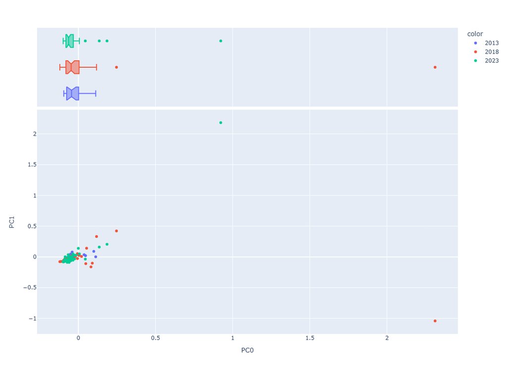

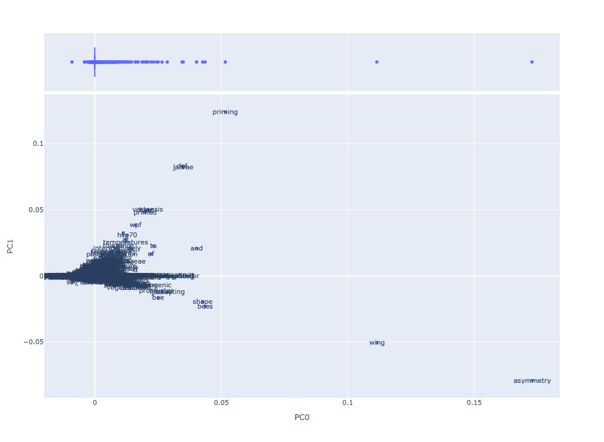

Briefly describe the nature of the polarity you see in the first component:

First Component

SECOND PLOT (LOADINGS, INCLUDES TOKENS): In the second plot, the graph is extremely skewed - one might say asymmetric as per the farthest skewed word "asymmetric" (pun intended!) - towards words on the right of the axis, with far fewer on the negative side of PC0. This presents some challenges to interpretation but does not make the task impossible. On the right, I see words about insects and non-mammals - wing, bees, vectensis, and on the left, I see fox, bats, and mouse - mammals. (This can be better seen in PCA.ipynb in the pannable, hover-label enabled plot.)

## PCA Visualization 2 (4)

Include a scatterplot of documents in the space created by the second two components.

Color the points based on a metadata feature associated with the documents.

Also include a scatterplot of the loadings for the same two components. (This does not need a feature mapped onto color.)

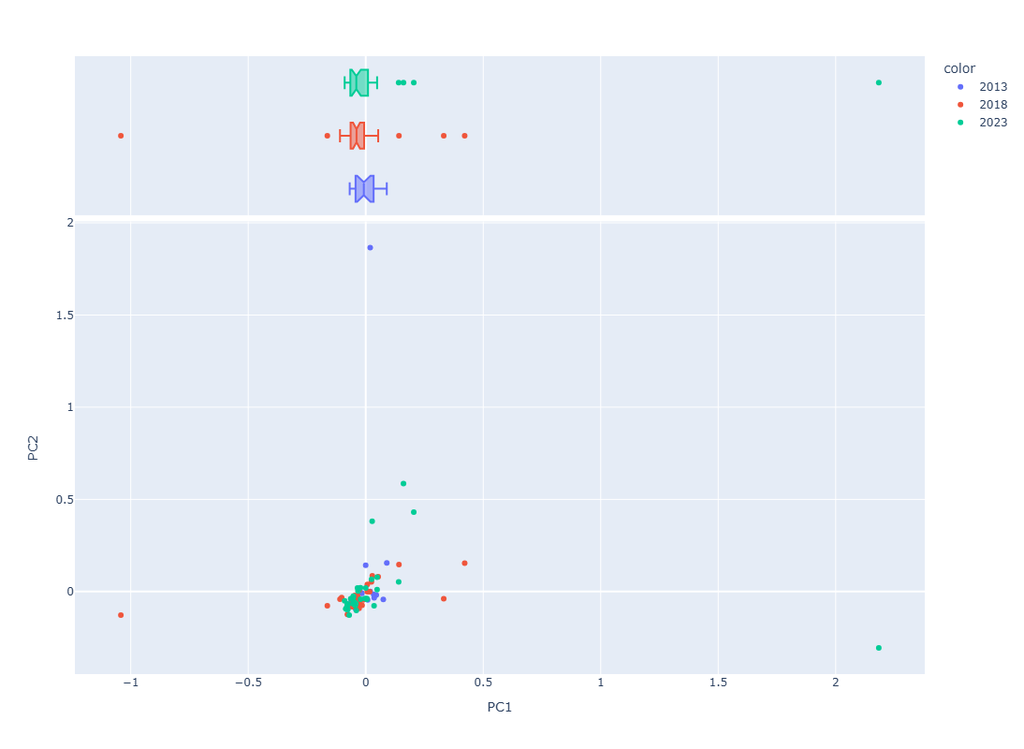

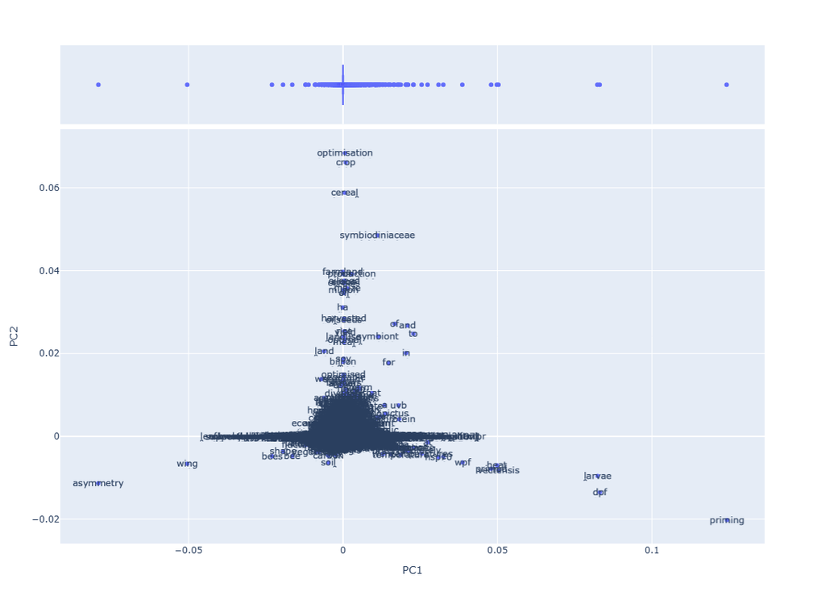

Briefly describe the nature of the polarity you see in the second component:

Second Component

SECOND PLOT (LOADINGS, INCLUDES TOKENS): In the second plot, many words are clustered along the axis for the second component, PC1. The ones that do extend positively and negatively past the axis are usually below the PC2 axis, which is interesting. Now, regarding significant words beyond stopwords (for, and, of), I see words like wing, bee, shape, soil, which are fairly colloquial words known to the non-scientific community, to the left of the axis, while more scientific words and abbreviations, like wpf, dpf, and vectensis, dominate the right side, so I hypothesize that is the distinction - common vs jargon - that this PC describes.

BONUS: Third Component

SECOND PLOT (LOADINGS, INCLUDES TOKENS):In the second plot, below the axis for PC2, I see many words that connect to insects and animals: vectensis (scientific name for a sea anenmoe) wing, bees, bee, larvae, even asymmetry (which in at least one document, refers to wing asymmetry). Above the axis, I see word that connect more to farming: land, crop, cereal, farmland. To slightly confuse this interpretation, I do see soil below the axis, albeit fairly close to zero. This could be because soil refers to farming, but also to the ground in which insects typically lay their larvae.

FIRST PLOT (PCA, YEAR METADATA): In the first plot, I see an intersting pattern: there are more high outliers above the axis for PC2 but fewer documents overall, while below the axis for PC2, there are more documents but with smaller values. I hypothesize that this is because the "farming" documents may be more sparse but use words that fall higher on the axis, as seen in the second plot (crop, cereal have fall high on the axis), giving the document a higher location on the axis (perhaps these words are more distinctive and unique to those documents?), while insect/animal-related documents are more "a dime a dozen."

## LDA TOPIC (4)

- UVA Box URL: https://virginia.box.com/s/hf5ujz5xz91eie5kee9kxfdy4v3nan84
- UVA Box URL of count matrix used to create: https://virginia.box.com/s/eeazv7i3oqz9tvm1936fombzwmyztxsk
- GitHub URL for notebook used to create: https://github.com/caroline-kranefuss/evolving_sentiment_climate/blob/main/notebooks/LDA.ipynb
- Delimitter: ,
- Libary used to compute: `sklearn.decomposition.LatentDirichletAllocation`
- A description of any filtering, e.g. POS (Nouns and Verbs only): English stopwords filtered out
- Number of components: 20 (0 through 19)
- Any other parameters used: max_df=.9, min_df=10, n_topics = 20, max_iter = 100, n_top_terms = 9
- Top 5 words and best-guess labels for first five topics:
  - T00: soil water soils content cm **Soil Science**
  - T01: fish prediction air quality protein **Aquatic Studies**
  - T02: city model cities public approaches **Urban Planning**
  - T03: populations population dna age number **Genetics**
  - T04: model areas models area precipitation **Climate Modeling**

BONUS

- Top 5 words and best-guess labels for top five topics by mean document weight:
  - T11 populations species population genetic habitat **Living Populations**
  - T04 model areas models area precipitation **Climate Modeling**
  - T05 temperature rates coral effects treatment **Oceans**
  - T17 species diversity samples sequences community **Living Populations** (repeat)
  - T16 species sites mm site native **Distribution**
- Top 5 words and best-guess labels for bottom five topics by mean document weight:
  - T10 carbon land storage area management **Land Management** (My volunteering here in Charlottesville at the Piedmont Environmental Council)
  - T14 sensor environmental monitoring sensors humidity **Climate Modeling** (repeat - fascinating that it's also a top 5 topic?)
  - T00 soil water soils content cm **Soil Science** (listed in first five topics)
  - T09 urban forest carbon landscape area **Land Management** (repeat)
  - T13 geographic transport modern scaled living **Human-Centered Studies**

## LDA THETA (4)

- UVA Box URL: https://virginia.box.com/s/lkqmbjdud7zvycsaocaqupkc5v8hrujv
- GitHub URL for notebook used to create: https://github.com/caroline-kranefuss/evolving_sentiment_climate/blob/main/notebooks/LDA.ipynb
- Delimitter: ,

## LDA PHI (4)

- UVA Box URL: https://virginia.box.com/s/hyziu7o2kvybqt35sga4g5xm9g0wuzoj
- GitHub URL for notebook used to create: https://github.com/caroline-kranefuss/evolving_sentiment_climate/blob/main/notebooks/LDA.ipynb
- Delimitter: ,

## LDA + PCA Visualization (4)

Apply PCA to the THETA table and plot the topics in the space opened by the first two components.

Size the points based on the mean document weight of each topic (using the THETA table).

Color the points basd on a metadata feature from the LIB table.

Provide a brief interpretation of what you see.

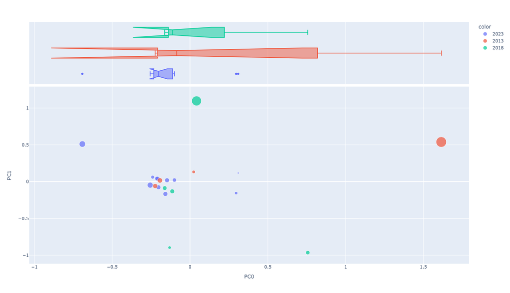

## Sentiment VOCAB_SENT (4)

Sentiment values associated with a subset of the VOCAB from a curated sentiment lexicon.

- UVA Box URL: https://virginia.box.com/s/xms6fyssrmllm7ba35jgntsbw1hxf5dj
- UVA Box URL for source lexicon: https://virginia.box.com/s/neecynsfnyso99fzgjxg6zuuopbu2u7j
- GitHub URL for notebook used to create: https://github.com/caroline-kranefuss/evolving_sentiment_climate/blob/main/notebooks/sentiment.ipynb
- Delimitter: ,

## Sentiment BOW_SENT (4)

Sentiment values from VOCAB_SENT mapped onto BOW.

- UVA Box URL: https://virginia.box.com/s/8uxfqi7sbgdob86vsp71jtf3em4velqw
- GitHub URL for notebook used to create: https://github.com/caroline-kranefuss/evolving_sentiment_climate/blob/main/notebooks/sentiment.ipynb
- Delimitter: ,

## Sentiment DOC_SENT (4)

Computed sentiment per bag computed from BOW_SENT.

- UVA Box URL: https://virginia.box.com/s/w86h1gzlkdgtn1e8xb0ya2kwucv2jtqi
- GitHub URL for notebook used to create: https://github.com/caroline-kranefuss/evolving_sentiment_climate/blob/main/notebooks/sentiment.ipynb
- Delimitter: ,
- Document bag expressed in terms of OHCO levels: 'YEAR'

## Sentiment Plot (4)

Plot sentiment over some metric space, such as time.

If you don't have a metric metadata features, plot sentiment over a feature of your choice.

You may use a bar chart or a line graph.

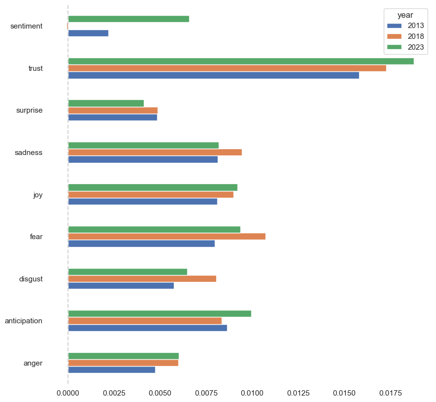

Trust is very high in all years and increases as the years progress. This is not surprising, as trust is a fundamental part of science. Interestingly, fear and sadness spike in 2018. This may be because the United Nations Intergovernmental Panel on Climate Change (IPCC) released a report in October 2018 with dire warnings about a point of no return in climate change; it made headlines at the time and its creation and publication may have spawned a lot of research. Surprise was steady in 2013 and 2018 but decreased in 2023, while anger was lowest in 2013 and steady from 2018-2023. Finally, sentiment was quite neutral in 2018 but positive in 2013 and even more highly positive in 2023. This is fascinating and I wonder if the fear and sadness spikes dragged 2018's overall sentiment down.

## VOCAB_W2V (4)

A table of word2vec features associated with terms in the VOCAB table.

- UVA Box URL: https://virginia.box.com/s/i2dqy9qp1tm902bp4kxafta96ixl9uju
- GitHub URL for notebook used to create: https://github.com/caroline-kranefuss/evolving_sentiment_climate/blob/main/notebooks/word2vec.ipynb
- Delimitter: ,
- Document bag expressed in terms of OHCO levels: 'year'
- Number of features generated: 1,498 term strings, 200 vectors
- The library used to generate the embeddings: `gensim.models.word2vec`

## Word2vec tSNE Plot (4)

Plot word embedding featues in two-dimensions using t-SNE.

Describe a cluster in the plot that captures your attention.

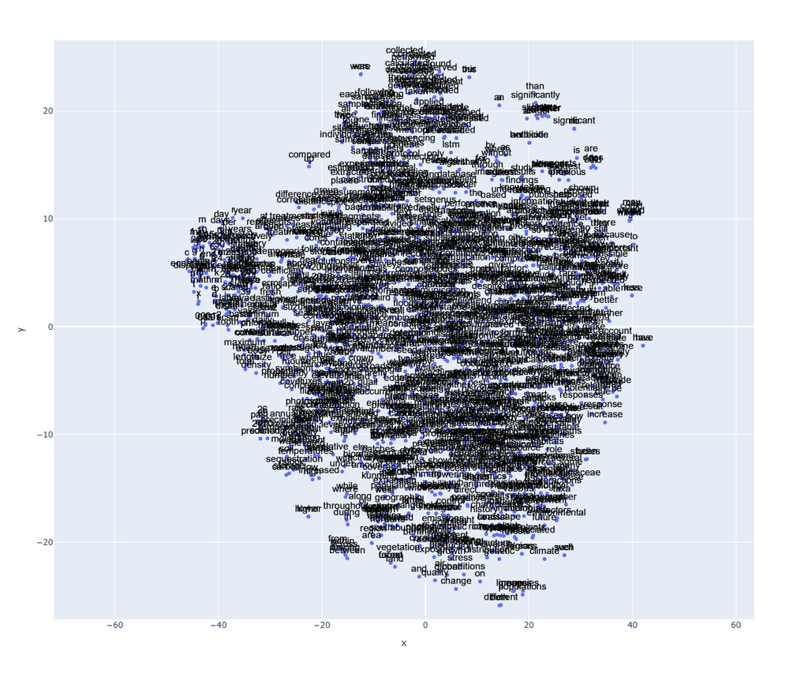

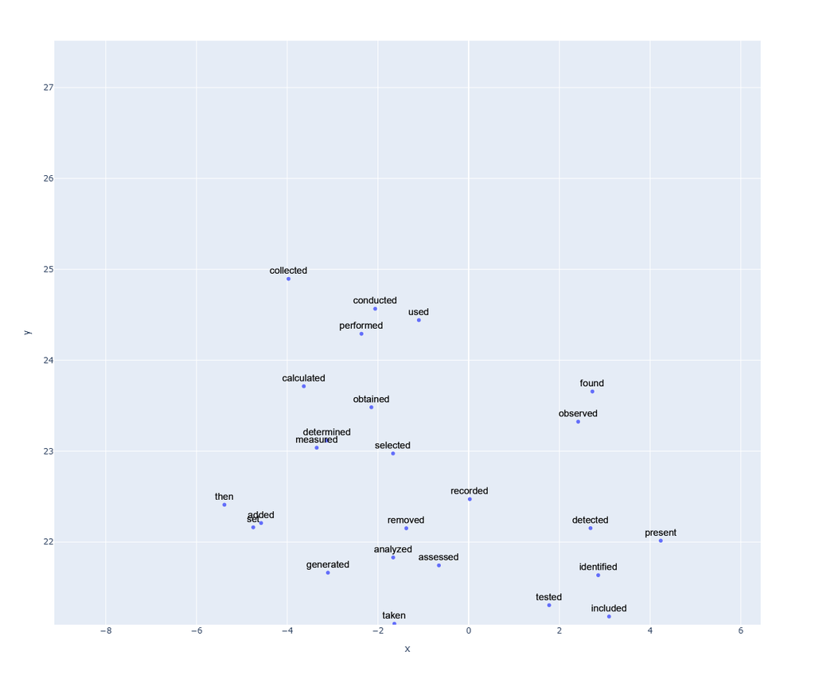

I see a fascinating distribution of words connected to data. Collected, conducted, performed, used, calculated, obtained, determined, measured, selected, recorded, found, observed, added, generated, analyzed, assessed, etc. It makes a lot of sense that this is a distinctive cluster because no matter the topic - climate change or otherwise - data is crucial to the scientific process.

# Riffs

Provde at least three visualizations that combine the preceding model data in interesting ways.

These should provide insight into how features in the LIB table are related.

The nature of this relationship is left open to you -- it may be correlation, or mutual information, or something less well defined.

In doing so, consider the following visualization types:

- Hierarchical cluster diagrams
- Heatmaps
- Scatter plots
- KDE plots
- Dispersion plots
- t-SNE plots
- etc.

## Riff 1 (5)

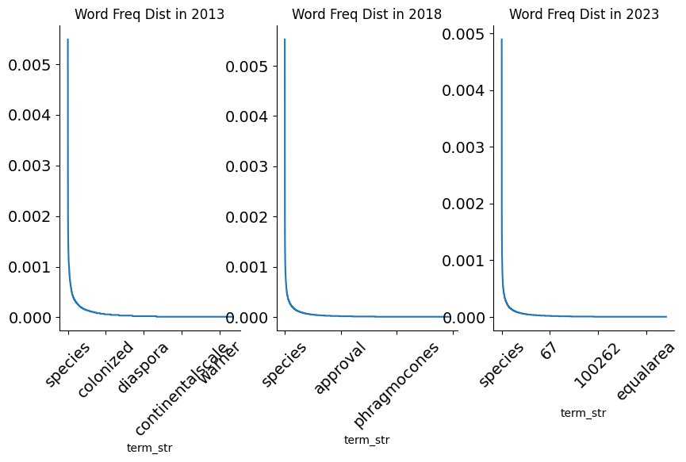

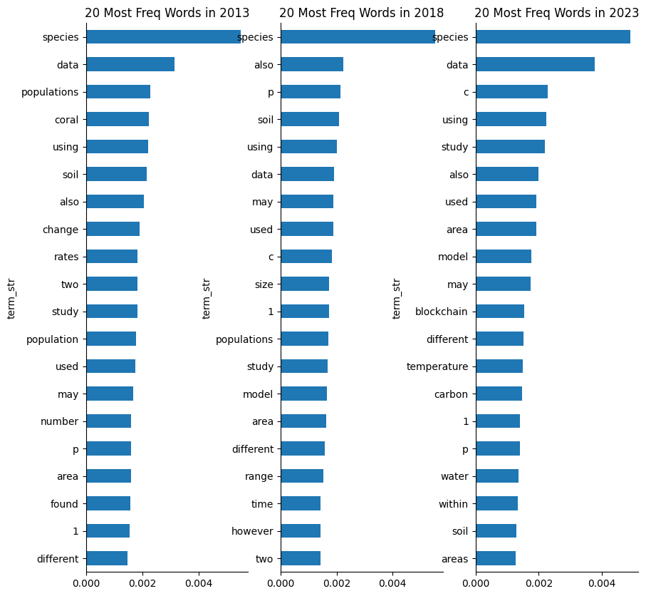

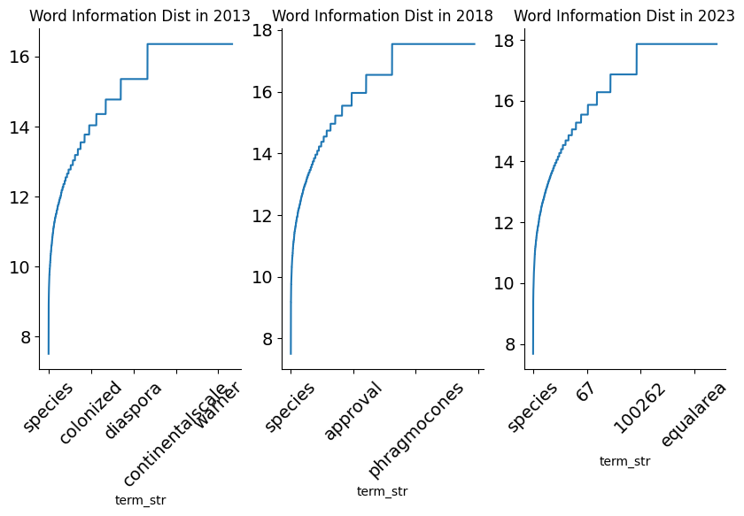

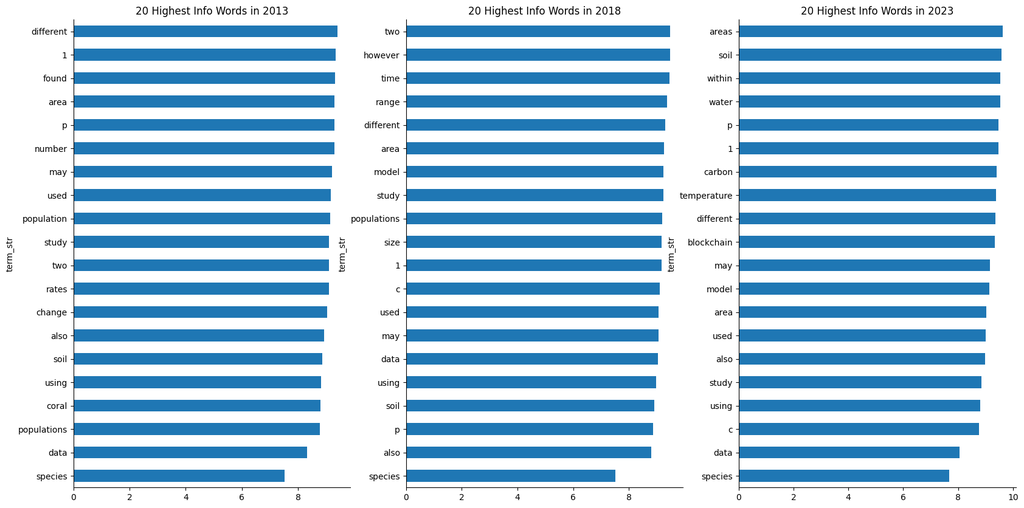

To complete this riff, I explored stopwords - only fair, since I removed them from the work above. I found that the distribution of stopwords over years generally remains constant - one year is not more heavily-laden with stopwords than others.

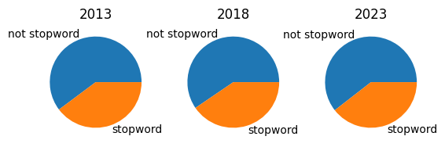

I also explored stopword information in the entire corpus. I found that stopwords and non-stopwords generally both have high information and have very similar means, but stopwords have a longer, lower tail of outliers:

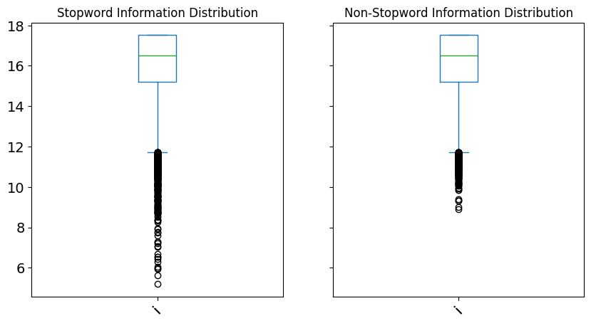

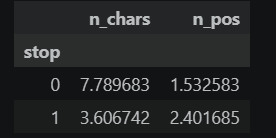

## Riff 2 (5)

I explored Latent Dirichlet Allocation more deeply for this riff.

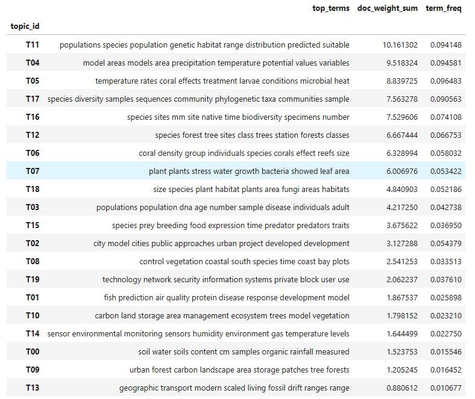

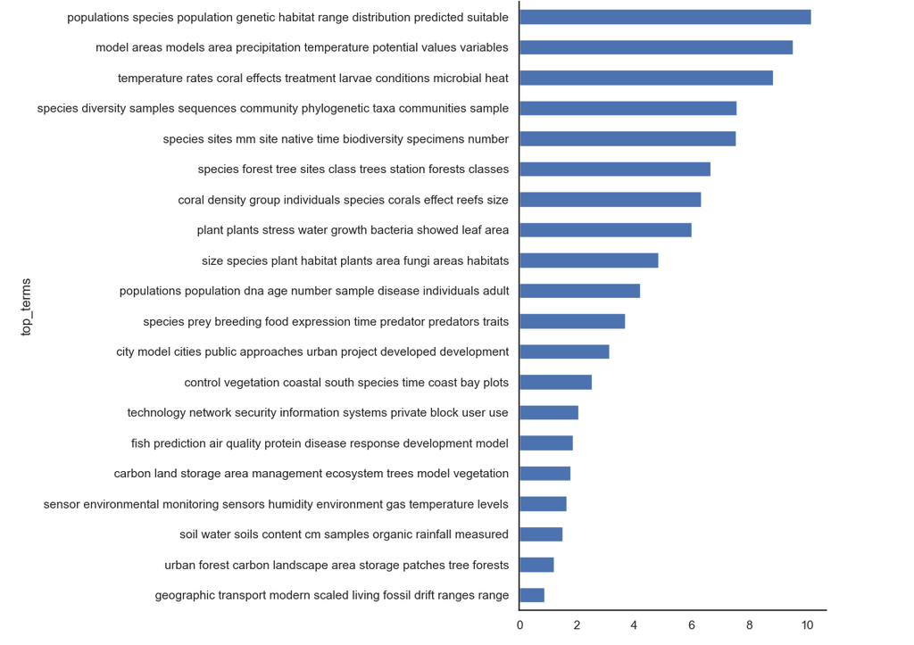

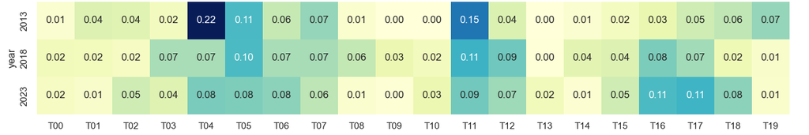

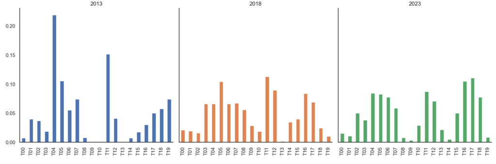

I'm particularly partial to Topic 4, "model areas models area precipitation temperature potential values variables", because they connect directly to my research! I am building a CNN to model robust and consistent signals of climate change in net-zero scenarios, looking at variables like precipipation and temperature to comprise these signals. That aside, this grouping makes sense and is an unsurprising second candidate for the list of topics. Climate change directly impacts rain and heat (and cold!) - changing those variables is how it devastates the planet, no matter which area connected to climate change one is studying.

Topic 13 is weighted least heavily, holding the terms "geographic transport modern scaled living fossil drift ranges range". I am suprised that range appears in both Topic 11 and Topic 13 - perhaps it means different things in different topics? Range has quite a range of meanings (sorry for the second pun) and maybe the Topic 11 discusses habitat ranges and population distributions and Topic 13 means the range that different scales hold.

To explore a topic in the middle, Topic 3 describes "populations population dna age number sample disease individuals adult". This is pretty interesting. Changes in climate can certainly impact disease and even manipulate individuals' DNA, but I wasn't expecting this to be its own topic, as it seems like a niche topic that I didn't see appearing in many of the articles' abstracts, but I suppose I missed or overloooked something - the benefit of LDA!

Topic 11 decreases in importance as each year progresses (populations species population genetic habitat range distribution predicted suitable) - perhaps adding credence to my technology-growth theory!

Topics 16 and 17 increase in importance as the years progress (T16 species sites mm site native time biodiversity specimens number; T17 species diversity samples sequences community phylogenetic taxa communities sample), which perhaps (and this could be stretch) refers to the growth in genetics-based research as technological capabilities have evolved the past decade (see the genetics program here at SDS!)

2013 seems to have the highest variation, with some very high highs and lots of low lows, while 2018 and 2023 are more balanced.

## Riff 3 (5)

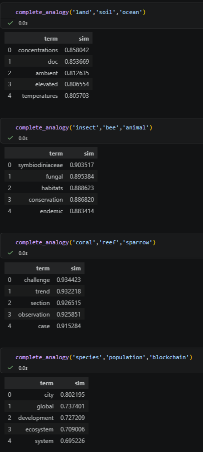

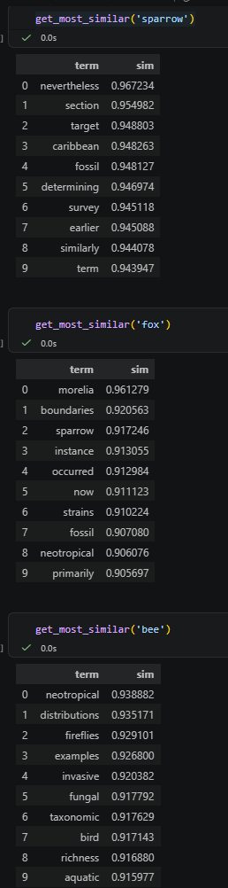

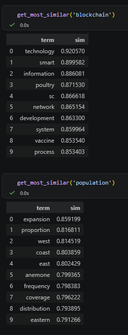

In my exploration of Word2Vec, I explored analogies and similarities. For these analogies, I chose to explore some concepts from the principal components. The analogies were not very accuracte:

Land is to soil as ocean is to ___ --> I was expecting to see water, since land is made up of soil and the ocean is made up of water, but the only mildly close word I found was ambient, which could refer to water temperature, but that is a bit of a stretch.

Insect is to be as animal is to __ --> I hypothesized I'd see fox or another animal, since a bee is a type of insect, but got mostly random words.

Coral is to reef as sparrow is to __ --> My guess was that I'd see tree or another structure in which sparrows live (even a figurative structure like a flock), given that coral grows on/in reefs, but again found random words.

Species is to population as blockchain is to __ --> This one was less well laid out but I wanted to explore the bio vs technical axis that I've hypothesized about throughout this project. This did yield some potentially interesting results, with words like city and global relating to blockchain (a new technology) in the same way that species and populations are similar words.

## BONUS

I also explored parts of speech in pos.ipynb. I found some interesting differences from typical pos patterns in my corpus. For example, in the plot below, the climate corpus has more ambiguous types AND tokens as compared to corpuses compiled by the Penn Treebank Project (drawn from the Wall Street Journal, WSJ, in ~1989) and Brown University in 1961 (both of which used Treebok-3 tagging). I wonder if this observation is connected to the fact that the WSJ and Brown come from editorial sources, while scientific definitions may have more ambiguity/multiple meanings, though this does frankly go against my conception of science as having singular definitions.

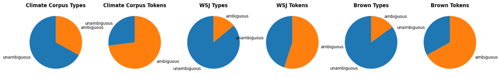

# Interpretation (4)

Describe something interesting about your corpus that you discovered during the process of completing this assignment.

At a minumum, use 250 words, but you may use more. You may also add images if you'd like.

I began this project with a curiousity about how sentiment has evolved over time in climate change-based scientific literature. I observed some trends described in the sentiment analysis section of this document, but ultimately, hesitate to deem those the real findings of my project - so far as to have adapted the formal title of my project from Changing Sentiment to Changing Trends in Climate Research, which also reflects the greater scope of work this project ended up encompassing. I am taking this section to describe why.

I begin with some photos of printed, color-coded sentences from the corpus that display words' and overall meanings' sentiments. I then examine how these sentiment assignments fit in a scientific context. For the sake of brevity, not every word discussed is displayed in the photos, but is seen in the corpus.

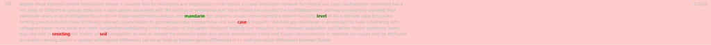

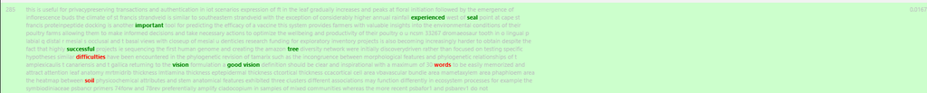

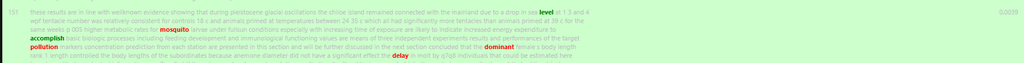

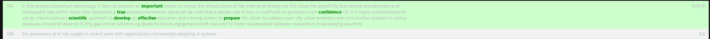

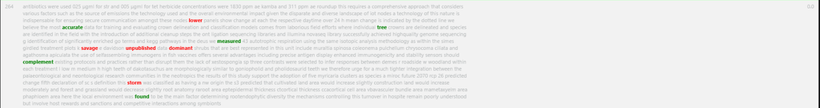

Of particular interest are the classification of mosquito, black, endemic, soil, and unpublished as negative words. Mosquitos are, of course, annoying to humans, but do play a crucial role in ecosystems; scientists generally believe no species has a positive or negative connation, though in literature, mosquitos may stand for irritating in a metaphor, and they do carry disease that can transmit to humans. Black is a tricky one: throughout literature, one can find references to black as a stand-in for darkness and sadness ('a black mood') but does this stem from racist motivations? (See Heathcliff's terrifying 'black' face described throughout Wuthering Heights as a demon or devil.) In the sentences I saw, black simply described the color of a fin - quite neutral. Soil can mean 'to dirty', so it gets negative sentiment, but as a noun referring to dirt, it is actually quite beneficial, or at the very least neutral! Finally, endemic means native of or to, which is in and of itself a neutral meaning. However, it can often refer to disease and I assume that is why it got classified as negative. Finally, a cheeky note that unpublished can stand in as a nod to the oft-stated "publish or perish" dilemma many scientists face.

Also of interest are the classification of perennial, tree, and dawn as positive words. A plant, specimen, or trend's perennial existence - as opposed to annual or shorter - is not necessarily a good thing. As noted above, scientists generally try to avoid assigning positive or negative meaning to these descriptors, as what is good for one instance is poor for another, so the application of sentiment here may not be entirely accurate. Trees are, of course, lovely things. They provide shade, filter carbon, serve as homes for legions of species... but they are also not "good" any more than a mosquito is "bad" - each just exists in its own place in an ecosystem. Finally, dawn has many a metaphorical meaning, most if not all positive, but, as per my refrain, is a neutral phenomenon in nature.

Finally, I was fascinated to see that the word scientific has a positive connotation here. The scientific method is often praised as an unbiased way to clearly see the world (see my cluster of data-related words in a plot above). It aims to be neutral - neither positive nor negative - even though scientific advances often help improve the world (or at least humans' experiences in it). Sometimes, as in the case of eugenics or big-sugar funded reseach on (you guessed it) sugar, scientific findings can be falsified or manipulated. (It is worth raising the question of whether this was really science to begin with.) But science at its best has no bias - so why has sentiment analysis classified it as a good word? Is it because the aimed lack of bias is in and of itself a good quality? Or is it a doe-eyed look at what people *think* science is, without a clear understanding of how badly it can go?

Because of these findings, I hesitate to assign real meaning to the sentiment analysis findings in this project. I can see how mosquito or dawn would be important signifiers of emotional tenor in literature. But in science, many of these words' connotations aim to be stripped away, leaving sentiment analysis bereft in an article's sea of mostly-neutral words.

Ultimately, I found more trustworthy results in my TF-IDF work. The hypothesis I'd arrived with - that the field would have shifted from being more biologically-based to more technologically-based - was not rejected.

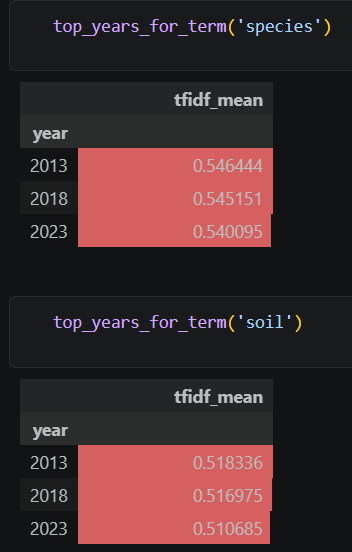

For example, the TFIDFs for species and for soil are relatively the same, respectively, per year, showing that these are consistently-used terms in climate science, not an exception or development used or phased out year by year. At a very granular level, species and soil are both slightly more important in 2013 and decreases very slightly over the years, which could add credence to my hypothesis and prior findings that climate science has become slightly less biologically-based in favor of more technological, computer/man-made based explorations over the years, but in truth, this difference is too small to make meaningful conclusions or statistically significant ones, especially given that the corpus is relatively small and does not encompass the entirety of climate literature for any given year.

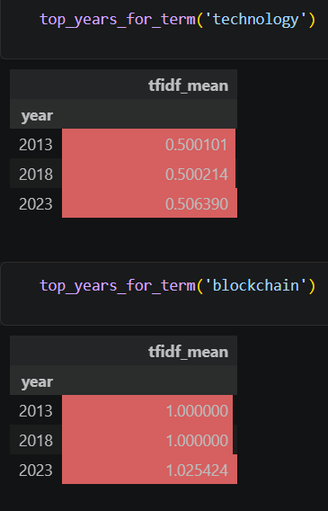

Exploring technological words like blockchain and technology yields similar results: a slight addition of credence to my hypothesis and prior findings but mostly statistically insignificant findings/consistency across the years. I am slightly surprised that blockchain has had such a similar TF-IDF in both 2013 and 2023, since it feels a more recent addition to climate science, but perhaps I am underestimating the technological proficiency of the field at the time (in 2013).

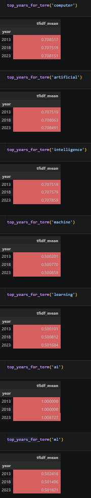

I finally explored words like computer, artifical, intelligence, machine, and learning. I did not expect great findings from this search since artifical and intelligence have a vastly different meaning when separate than when together (same for machine and learning) but thought it was worth a peek. Indeed, TF-IDF is nearly identical (often down to the ten-thousandth's place) for all three years.

A fascinating discovery was the fact that ai and ml still follow this pattern! I am curious about this, but perhaps I am digging for meaning where there is none here - AI and ML have been in development since before 2013 (though it did not become part of the public consciousness until after 2020 as far as I know), and climate science, with its massive datasets and forward-thinking nature, has always well-poised to take advantage of the latest advancements in science and technology alike.

Finally, I explored terms with the highest TF-IDF per year.

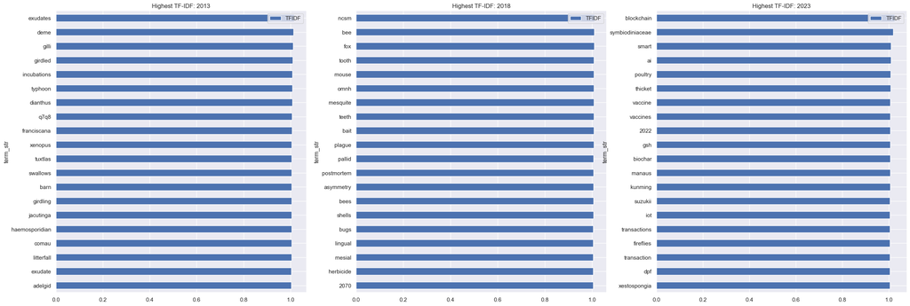

In 2013, those were exudates, deme, gilli, girdled, incubations, typhoon, dianthus, q7q8, franciscana, tuxtlas, xenopus, swallows, barn, girdling, jacutinga, haemosporidian, litterfall, comau, adelgid, and exudate. In 2018, those were ncsm, bee, fox, mouse, tooth, omnh, mesquite, teeth, bait, plague, pallid, postmortem, asymmetry, bees, shells, bugs, lingual, mesial, herbicide, and 2070.  
In 2023, those were blockchain, symbiodiniaceae, smart, ai, poultry, thicket, vaccine, vaccines, 2022, gsh, biochar, manaus, kunming, suzukii, iot, fireflies, transactions, transaction, xestospongia, and dpf.

Scientific names dominate the TF-IDF chart in 2013, while species dominate 2018. This differentiation is very interesting. I wonder at the shift from scientific names to common ones. Perhaps an attempt to make science more accessible? In 2023, we see blockchain, iot (internet of things), and vaccines appear, which, to me is unsurprising given their "buzziness" in the past three years. However, we still see scientific names AND common animal names. I wonder at this reintroduction of scientific names in 2023, but it may just be due to small sample size.

Finally, I explored sentence generation with n-grams for each year separately, Overall, the sense of sentences generated is about consistent between years (meaning, each year's generated text has similar levels of nonsensicality vs sensicality). 2013 and 2018 tend to describe typical biological phenomena ("HOW INSECT RESPONSES TO EXPERIMENTAL ROAD SALT AFFECTED THESE PERFORMANCE VARIABLES" in 2013 and "AMBIGUITIES WITHIN THE SYDNEY BASIN BIOREGION AN AREA ECOLOGICALLY IT IS CONCOMITANTLY NOTED THAT DETERMINING THE EVENT SIZE RAINFALL FREQUENCY IS BENEFICIAL GIVEN THE INHERENTLY LOW ABUNDANCE OF VERTEBRATE CLADES PRESERVED AT THESE LOCALITIES DIFFERENT TAPHONOMIC FACTORS ARE ALSO PROVIDED" in 2018). On the flip side, in 2023, we see the first mentions of technologies like software ("4 HOMOLOGY MODELLING 2 THREADING AND 3 CREATE PROGRAMS THAT CATER TO THIS WERE THE DRIVING FACTOR WAS EVALUATED USING MEGA 11 SOFTWARE WITH 1000 BOOTSTRAP REPLICATES USING UFBOOT2 AND THE BOYCE INDEX 093"). These are fascinating findings - climate science, from this very brief foray, seems to have shifted from examining only the natural world to both that and the technological one.

My overall conclusions very much interset me. My initial goal was to examine sentiment, and there were some interesting findings about negativity in 2018 and overall trust in each year, but I found the words' classifications fit more in a literary sense than in a scientific sense, so ultimately did not put too much weight on my sentiment findings. More strong were my findings about TF-IDF, term frequency, and word importance which, although findings were neither drastic nor statistically examined, validated to some extent my hypothesis that the field would begin to lean more technological (studying recent technology) in 2023 as opposed to 5 or 10 years earlier. Of course, much work remains to be done, and a larger corpus would only help my research, as well as the inclusion of more dates - trying to find HTML that predate 2013, examining dates between 2013 and 2023 not on the five-year mark, and seeing if research from this and last year follow these trends are all great places to take this next.